# Predicting Loan Default: Random Forest vs. Logistic Regression

A lender wants to flag loans likely to be **charged off** before extending credit, using an 86,138-loan historical dataset (LendingClub-style, 34 raw fields). Two models are compared head-to-head: a **ridge-regularized Logistic Regression** baseline and a **Random Forest**, both corrected for the same class imbalance in a comparable way, so the comparison isolates the effect of model choice rather than confounding it with different imbalance handling.

**Target:** `charged_off` (1 = loan defaulted, 0 = fully paid) — **18.8%** positive class.

## 1. Feature selection

Three columns are deliberately **excluded**, each for a different reason:

- **`last_pymnt_amnt` — data leakage.** Median last payment is **$2,997** for fully-paid loans vs. just **$387** for charged-off ones. That gap doesn’t describe credit risk — it *is* the outcome (a defaulted loan stops being paid). Including it would let the model “cheat” with information that isn’t available at the time a real lending decision is made.
- **`funded_amnt` — near-duplicate of `loan_amnt`** (nearly collinear).
- **`sub_grade`, `application_type`, `emp_title`, `title`, `zip_code`, `addr_state`** — redundant, constant, or high-cardinality identifiers not suited to this model.

`fico_range_low`/`fico_range_high` are collapsed into a single `fico_avg`, since the two are almost perfectly correlated.

```r
df <- read.csv("loandefault.csv", stringsAsFactors = FALSE)
df$fico_avg <- (df$fico_range_low + df$fico_range_high) / 2

numeric_features <- c("loan_amnt", "int_rate", "installment", "annual_inc", "dti",
                       "fico_avg", "open_acc", "revol_util", "acc_open_past_24mths",
                       "avg_cur_bal", "bc_open_to_buy", "bc_util", "mo_sin_old_rev_tl_op",
                       "mo_sin_rcnt_rev_tl_op", "mort_acc", "num_actv_rev_tl")
categorical_features <- c("term", "grade", "home_ownership", "verification_status",
                           "purpose", "initial_list_status", "emp_length")

model_df <- df[, c(numeric_features, categorical_features, "charged_off")]
model_df$emp_length[is.na(model_df$emp_length) | model_df$emp_length == ""] <- "Unknown"

# Median-impute the numeric columns with missing values (bc_util, bc_open_to_buy, revol_util)
for (col in numeric_features) {
  med <- median(model_df[[col]], na.rm = TRUE)
  model_df[[col]][is.na(model_df[[col]])] <- med
}

model_df[categorical_features] <- lapply(model_df[categorical_features], as.factor)
model_df$charged_off <- as.factor(model_df$charged_off)

cat("Feature matrix:", nrow(model_df), "rows x", ncol(model_df) - 1, "predictors\n")
```

```
## Feature matrix: 86138 rows x 23 predictors
```

```r
print(round(prop.table(table(model_df$charged_off)), 3))
```

```
##
##     0     1
## 0.812 0.188
```

## 2. Train/test split

A split **stratified by outcome** preserves the 81/19 class balance in both sets.

```r
set.seed(42)
n <- nrow(model_df)
train_idx <- unlist(lapply(split(seq_len(n), model_df$charged_off), function(idx) {
  sample(idx, size = floor(0.75 * length(idx)))
}))
train <- model_df[train_idx, ]
test  <- model_df[-train_idx, ]
cat("Train:", nrow(train), " Test:", nrow(test), "\n")
```

```
## Train: 64603  Test: 21535
```

## 3. Two models, one imbalance-handling philosophy

Both models are corrected for the 81/19 imbalance — a model that ignores it can reach 81% accuracy by predicting “no default” for everyone, which is useless for actually flagging risk. The *mechanism* differs by model, for reasons specific to each R package:

- **Logistic Regression** uses `glmnet` with **ridge-penalized** (`alpha = 0`), **case-weighted** regression, with the penalty strength chosen by 5-fold cross-validation. Base R’s `glm()` was tried first and produced wildly unstable coefficients (odds ratios in the thousands) for a couple of rare category levels — a direct consequence of `glm()` having **no regularization** by default, unlike scikit-learn’s `LogisticRegression`, which is L2-penalized out of the box. `glmnet` restores that same regularization.
- **Random Forest** uses `randomForest`’s `sampsize`/`strata` arguments (balanced bootstrap sampling within each tree) rather than its `classwt` parameter. `classwt` was tried first and over-corrected so hard that the model flagged 99% of loans as high-risk (recall near 1, accuracy near 0.25) — a known rough edge of that parameter. `sampsize`/`strata` is the more standard fix for class imbalance in this package.

```r
# ---- Logistic Regression: ridge-penalized, class-weighted, CV-tuned ----
x_train <- model.matrix(charged_off ~ . - 1, data = train)
x_test  <- model.matrix(charged_off ~ . - 1, data = test)[, colnames(x_train)]
y_train <- train$charged_off

w <- table(y_train)
w <- as.numeric(nrow(train) / (2 * w[y_train]))

set.seed(42)
cvfit <- cv.glmnet(x_train, y_train, family = "binomial", alpha = 0, weights = w, nfolds = 5)
logreg_prob <- as.numeric(predict(cvfit, newx = x_test, s = "lambda.min", type = "response"))
logreg_pred <- factor(ifelse(logreg_prob > 0.5, 1, 0), levels = levels(test$charged_off))

# ---- Random Forest: balanced sampsize/strata ----
min_class_n <- min(table(train$charged_off))
set.seed(42)
rf <- randomForest(charged_off ~ ., data = train, ntree = 400, maxnodes = 40,
                    sampsize = c(min_class_n, min_class_n), strata = train$charged_off,
                    importance = TRUE)
rf_prob <- predict(rf, newdata = test, type = "prob")[, "1"]
rf_pred <- predict(rf, newdata = test, type = "response")

summarize <- function(name, actual, pred, prob) {
  cm <- table(actual, pred)
  tp <- cm["1","1"]; fp <- cm["0","1"]; fn <- cm["1","0"]; tn <- cm["0","0"]
  precision <- tp / (tp + fp); recall <- tp / (tp + fn)
  f1  <- 2 * precision * recall / (precision + recall)
  acc <- (tp + tn) / sum(cm)
  auc_val <- as.numeric(auc(roc(actual, prob, quiet = TRUE)))
  data.frame(Model = name, Accuracy = acc, Precision = precision,
             Recall = recall, F1 = f1, ROC_AUC = auc_val)
}

results <- rbind(
  summarize("Logistic Regression (glmnet)", test$charged_off, logreg_pred, logreg_prob),
  summarize("Random Forest", test$charged_off, rf_pred, rf_prob)
)
knitr::kable(results, digits = 3)
```

| Model | Accuracy | Precision | Recall | F1 | ROC_AUC |
| --- | --- | --- | --- | --- | --- |
| Logistic Regression (glmnet) | 0.667 | 0.316 | 0.669 | 0.430 | 0.732 |
| Random Forest | 0.618 | 0.291 | 0.721 | 0.415 | 0.726 |

## 4. Confusion matrices

```r
cat("Logistic Regression (rows = actual, cols = predicted)\n")
```

```
## Logistic Regression (rows = actual, cols = predicted)
```

```r
print(table(Actual = test$charged_off, Predicted = logreg_pred))
```

```
##       Predicted
## Actual     0     1
##      0 11655  5841
##      1  1336  2703
```

```r
cat("\nRandom Forest (rows = actual, cols = predicted)\n")
```

```
##
## Random Forest (rows = actual, cols = predicted)
```

```r
print(table(Actual = test$charged_off, Predicted = rf_pred))
```

```
##       Predicted
## Actual     0     1
##      0 10396  7100
##      1  1125  2914
```

## 5. What drives the prediction?

```r
imp <- importance(rf)
imp_sorted <- imp[order(-imp[, "MeanDecreaseGini"]), ]
cat("Top 10 Random Forest feature importances (Mean Decrease in Gini)\n")
```

```
## Top 10 Random Forest feature importances (Mean Decrease in Gini)
```

```r
print(round(head(imp_sorted[, "MeanDecreaseGini", drop = FALSE], 10), 1))
```

```
##                      MeanDecreaseGini
## int_rate                        539.4
## grade                           461.6
## term                            269.4
## dti                              71.3
## fico_avg                         65.5
## verification_status              42.8
## loan_amnt                        37.1
## bc_open_to_buy                   35.0
## acc_open_past_24mths             34.2
## avg_cur_bal                      32.9
```

```r
co <- as.numeric(coef(cvfit, s = "lambda.min"))
names(co) <- rownames(coef(cvfit, s = "lambda.min"))
odds <- exp(co[names(co) != "(Intercept)"])
cat("\nTop 6 odds ratios (raise default risk)\n")
```

```
##
## Top 6 odds ratios (raise default risk)
```

```r
print(round(sort(odds, decreasing = TRUE)[1:6], 3))
```

```
## purposesmall_business        term 60 months     emp_lengthUnknown
##                 1.541                 1.502                 1.412
##                gradeE                gradeD                gradeC
##                 1.410                 1.405                 1.347
```

```r
cat("\nBottom 6 odds ratios (lower default risk)\n")
```

```
##
## Bottom 6 odds ratios (lower default risk)
```

```r
print(round(sort(odds)[1:6], 3))
```

```
##         purposewedding         term 36 months      emp_length5 years
##                  0.033                  0.663                  0.883
##      emp_length9 years      emp_length4 years home_ownershipMORTGAGE
##                  0.902                  0.907                  0.915
```

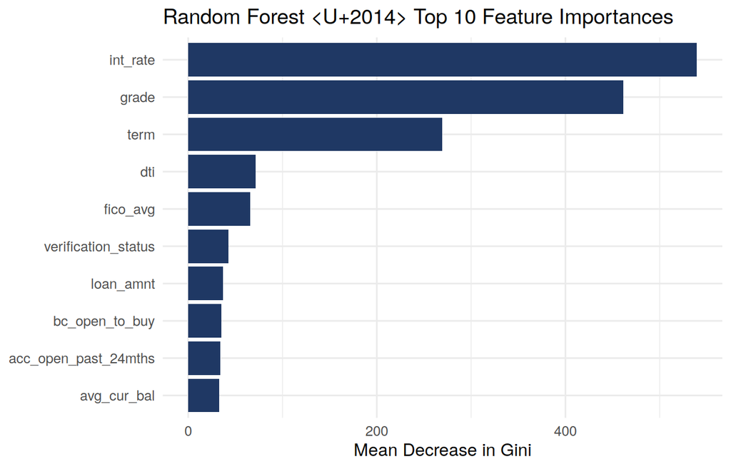

```r
top10 <- head(imp_sorted[, "MeanDecreaseGini", drop = FALSE], 10)
plot_df <- data.frame(feature = factor(rownames(top10), levels = rev(rownames(top10))),
                       importance = top10[, 1])
ggplot(plot_df, aes(x = feature, y = importance)) +
  geom_col(fill = "#1F3864") + coord_flip() +
  labs(title = "Random Forest — Top 10 Feature Importances",
       x = NULL, y = "Mean Decrease in Gini") +
  theme_minimal(base_size = 12)
```